# White Wine Quality Exploration by Josh See

### pH vs fixed.acidiy vs Quality

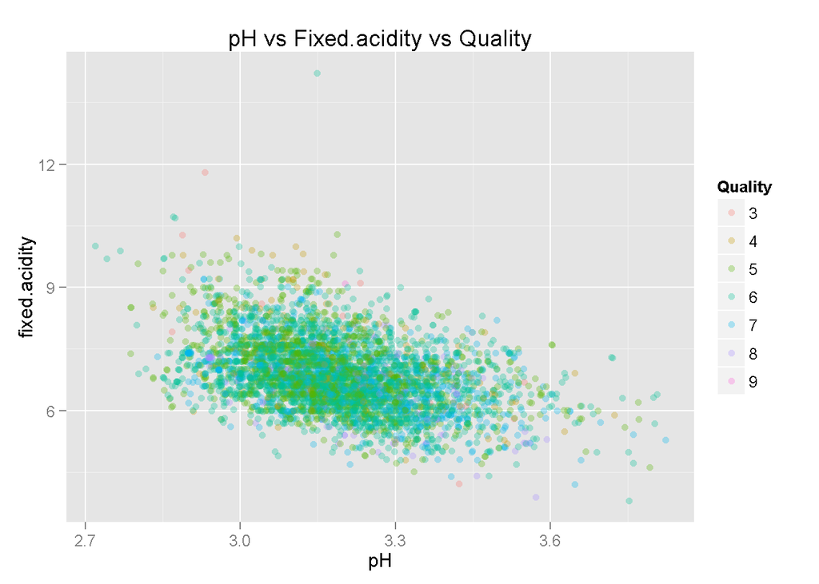

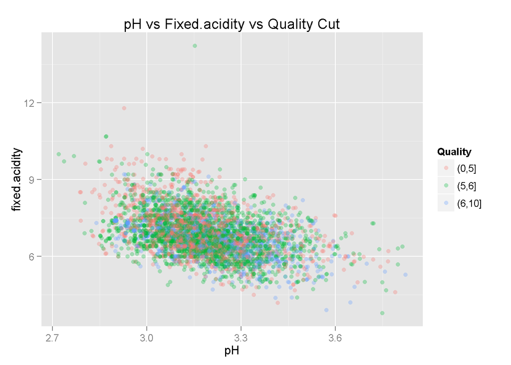

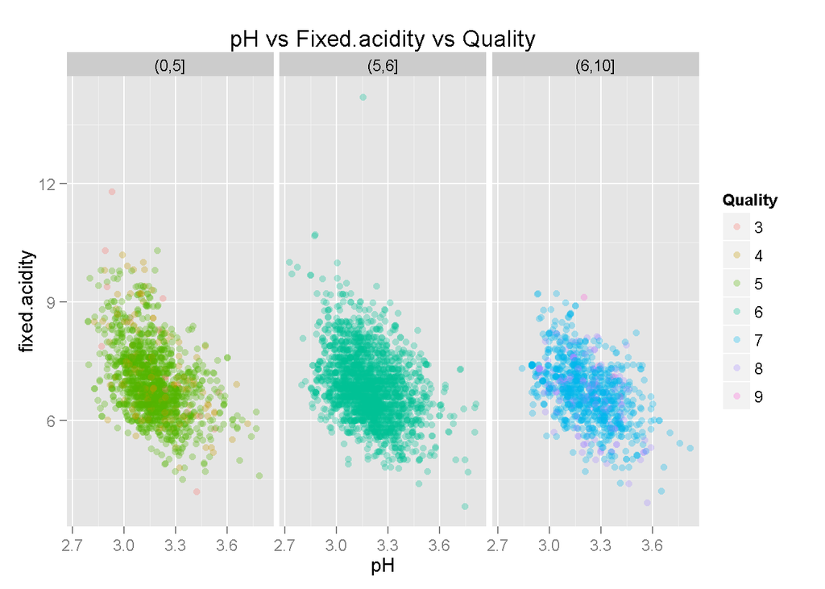

Initially, I thought `pH` has a little bit of correlation with `quality`. Thus `pH` vs `fixed.acidity` should somewhat linked with `quality`. After plotting it out there seems no strong pattern that we can identify from `pH` vs `fixed.acidity` vs `quality`.

# Multivariate Analysis

### Talk about some of the relationships you observed in this part of the investigation. Were there features that strengthened each other in terms of looking at your feature(s) of interest?

The relationship between `density` and `residual.sugar` and `alcohol` seems quite interesting. Since all of them are highly correlated with one another, it is easy to spot the changes as any one of the variable varies. When we swapped out `alcohol` with `quality` score the same correlation can be spotted as well.

### Were there any interesting or surprising interactions between features?

As I mentioned above, I thought `pH` would provide some interaction with `quality`. But after plotting it out. It’s a bit hard to identify it from the plot.

### OPTIONAL: Did you create any models with your dataset? Discuss the strengths and limitations of your model.

# Final Plots and Summary

### Plot One

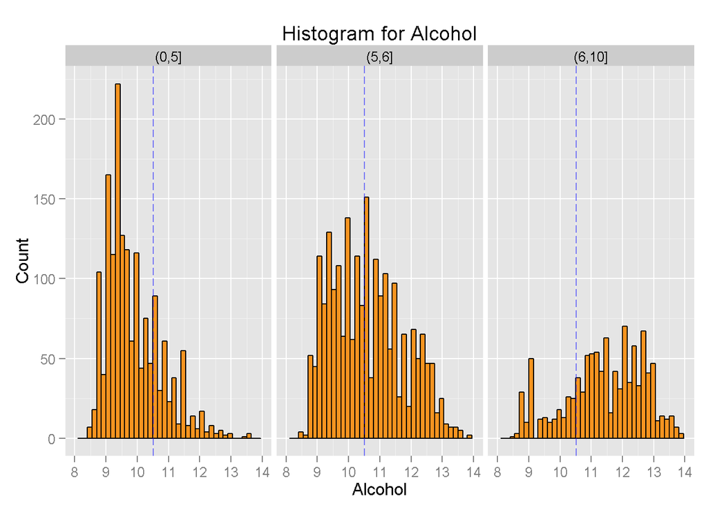

### Description One

When the histogram is facet by quality score cut. We can see that bad quality score wines show a positive skewed towards lower alcohol level. Average quality score wines shows us more of a shape of normal distribution of alcohol. Best quality score shows a negatively skewed distribution towards higher alcohol level.

### Plot Two

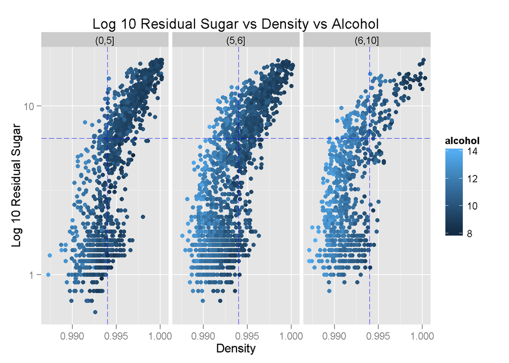

### Description Two

This graph shows that as `density` and `residual sugar` increase, `alcohol` level decreases. This can be clearly seen in best quality score wines where the color goes from light to dark. Even thought the same color variation applies to average quality score wines and bad quality score wines but its not that significant.

### Plot Three

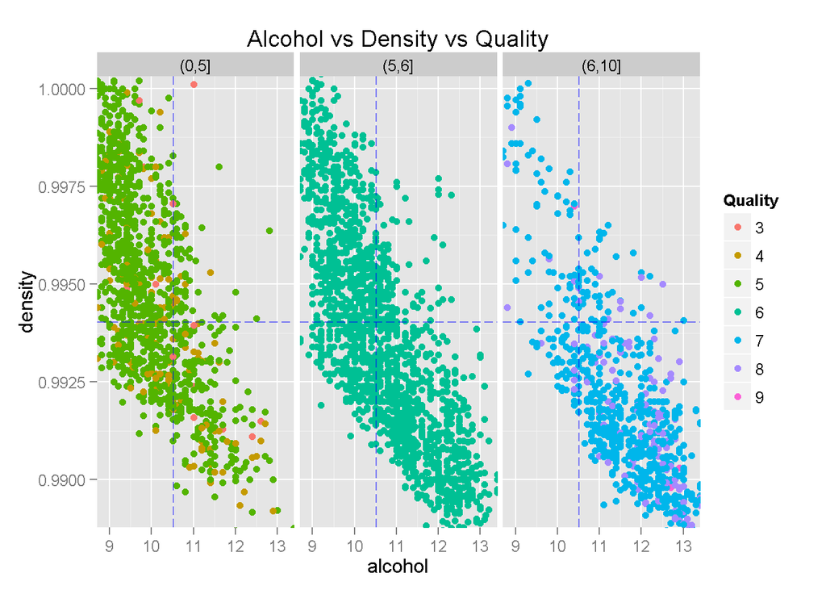

# Reflection

There are two difficulties which I encountered during the analaysis. One, the lack of categorical variables. In the dataset there is only one categorical variable that we can use which is `quality`, I wish that there were more variables like that as it would allow us to identify more relationship between the variables using subset. Two, the lack of correlations between variables. There are some variables that shows very low correlation with any other variables.

Even with the limitation that we had in our dataset, we are still able to discover very interesting findings such as `alcohol` and `density` and `residual.sugar`. I was only able to identify a few of them to understand its influvence over `quality` score from a scatterplot matrix.

There are many other factors that can determine a good wine. Things like smells and flavours and not chemical properties can be documented in the dataset to allow us to explore further to find out what is a good quality wines.